# Lab 3: Mine Crafting

## Part 4: An infinitely deep mine

Now, let us consider the theoretical case of an infinitely deep mine -- that is, a tunnel which traverses the full diameter of the Earth. For convenience, imagine the tunnel goes from pole-to-pole, such that $\vec{\Omega} \times \vec{v} = 0$, and the Coriolis force can be neglected, as well as the drag force.

Additionally, continue assuming a constant density Earth.

1. Again, plot the depth and velocity as a function of time. (Be careful with the meaning of $y$, as the particle can theoretically traverse fully through to the other side of the Earth.) Comment on what you see in the graph.  
   In your notebook, label this figure clearly as **Figure 4**.
2. How long will it take for the object to reach the other side? At what time does the object reach the center of the Earth, and at what speed?
3. How does this ``crossing-time" compare to the orbital period, where you assume the object is on a circular orbit, in centripetal balance with the attractive force of the gravity. \begin{equation} \frac{v^2}{R} = \frac{GM}{R^2} \tag{7} \end{equation} gives the orbital speed $v$ for a given Earth radius $R$ and Earth mass $M$.

```
The mass oscillates sinusoidally in simple harmonic motion
```

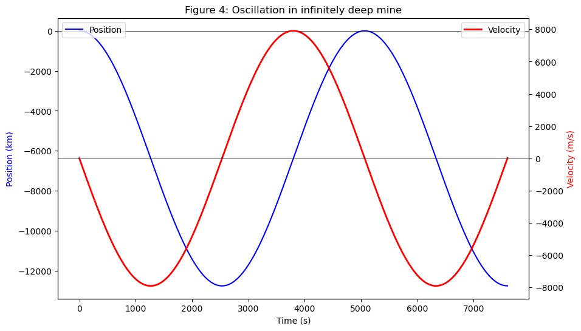

```python
#part 1
#for infinite mine: g(r) = g0 * r/R_e (linear with radius)
def motion_infinite_mine(t, state):
    y, v = state
    r = R_e + y
    g_r = g * r / R_e
    dydt = v
    dvdt = -g_r
    return [dydt, dvdt]

#this creates shm so i can integrate for full period
T_analytical = 2 * np.pi * np.sqrt(R_e / g)
t_span_long = (0, T_analytical * 1.5)
t_eval_long = np.linspace(0, T_analytical * 1.5, 2000)

sol_inf = solve_ivp(motion_infinite_mine, t_span_long, init0,
                    t_eval=t_eval_long, dense_output=True)

#plot - Figure 4
fig, ax1 = plt.subplots(figsize=(10, 6))
ax1.plot(sol_inf.t, sol_inf.y[0]/1000, label='Position', color='blue')
ax1.set_xlabel('Time (s)')
ax1.set_ylabel('Position (km)', color='blue')
ax1.legend(loc='upper left')
ax1.axhline(0, color='black', linewidth=0.5)

ax2 = ax1.twinx()
ax2.plot(sol_inf.t, sol_inf.y[1], color='red', linewidth=2, label='Velocity')
ax2.set_ylabel('Velocity (m/s)', color='red')
ax2.legend(loc='upper right')
ax2.axhline(0, color='black', linewidth=0.5)

plt.title('Figure 4: Oscillation in infinitely deep mine')

print("The mass oscillates sinusoidally in simple harmonic motion")
```

```python
#part 2
#find when y = -R_e (center of Earth)
center_idx = np.argmin(np.abs(sol_inf.y[0] + R_e))
t_center = sol_inf.t[center_idx]
v_center = sol_inf.y[1][center_idx]

#find when y = -2*R_e (other side)
other_side_idx = np.argmin(np.abs(sol_inf.y[0] + 2*R_e))
t_other_side = sol_inf.t[other_side_idx]

print(f"Time to reach center: {t_center:.1f} s = {t_center/60:.1f} min")
print(f"Speed at center: {abs(v_center):.1f} m/s")
print(f"Time to reach other side: {t_other_side:.1f} s = {t_other_side/60:.1f} min")
```

```
Time to reach center: 1266.2 s = 21.1 min
Speed at center: 7909.1 m/s
Time to reach other side: 2555.1 s = 42.6 min
```

```python
#part 3
#orbital speed at Earth's surface: v = sqrt(GM/R)
v_orbital = np.sqrt(G * M_e / R_e)
T_orbital = 2 * np.pi * R_e / v_orbital
print(f"Crossing time (one way): {t_other_side:.1f} s = {t_other_side/60:.1f} min")
print(f"Orbital period: {T_orbital:.1f} s = {T_orbital/60:.1f} min")
print(f"Ratio (crossing/orbital): {t_other_side/T_orbital:.3f}")
```

```
Crossing time (one way): 2555.1 s = 42.6 min
Orbital period: 5069.4 s = 84.5 min
Ratio (crossing/orbital): 0.504
```

The ratio of $T_{Cross}$ to $T_{Orb}$ is very nearly $0.5$, meaning the crossing time equals one half of an orbital period.

## Part 5: A non-uniform Earth

Finally, let us consider the case of a non-uniform Earth, and continue assuming we have no drag. We know from geology that the density increases towards the center. It rises from about 2-3 g/cm$^3$ near the surface, to more like 13 near the center. A simple model for the density $\rho$ as a function of distance from the center of the Earth $r$ is:

$$ \rho(r) = \rho_n \left( 1 - \frac{r^2}{R_{\oplus}^2} \right)^n \tag{8} $$

where $n$ is some exponent, and $\rho_n$ is a normalizing constant. The case of $n=0$ is the constant density Earth, while $n=2$ is closer to the real value. Note that the total mass of the Earth, $M$, must be conserved. Since the mass is the volume integral over the density:

\begin{equation} M = \int_V \rho(r) dV = \int_0^{2\pi} \int_0^{\pi} \int_0^{R_{\oplus}} \rho(r) r^2 \sin \phi \, dr \, d\phi \,d\theta = 4 \pi \int_0^{R_{\oplus}} \rho(r) r^2 \, dr \tag{9} \end{equation}

you will need to recompute the density constant $\rho_n$ for each case of $n>0$, You can use the `quad` integrator for this. Note that the analytic solution is straightforward to do by hand for $n=0$, and still manageable for $n=1,2$. You might consider doing that integral to make sure your method is right, and then you can be confident for $n>0$.

1. Plot the normalized density profile (that is, set $\rho_n=1$) as a function of radius for $n=0, 1, 2, 9$.  
   Put them all on the same plot, with a clear legend.  
   In your notebook, label this figure clearly as **Figure 5**.
2. Now, plot the force profile as a function of radius for $n=0, 1, 2, 9$.  
   This step will show you if your normalization factor $\rho_n$ is correct, because the surface force must be the same for all $n$.  
   In your notebook, label this figure clearly as **Figure 6**.
3. Then, plot the position and velocity as a function of time for $n=0, 1, 2, 9$ as you did in Figure 1/2.  
   In your notebook, label this figure clearly as **Figure 7**.
4. For $n=0, 1, 2, 9$, compute the time to reach the center, and the speed achieved there.

### Part 5, Section A (Density)

```
n=0: ρ_n = 5.49e+03 kg/m^3
n=1: ρ_n = 1.37e+04 kg/m^3
n=2: ρ_n = 2.40e+04 kg/m^3
n=9: ρ_n = 1.36e+05 kg/m^3
```

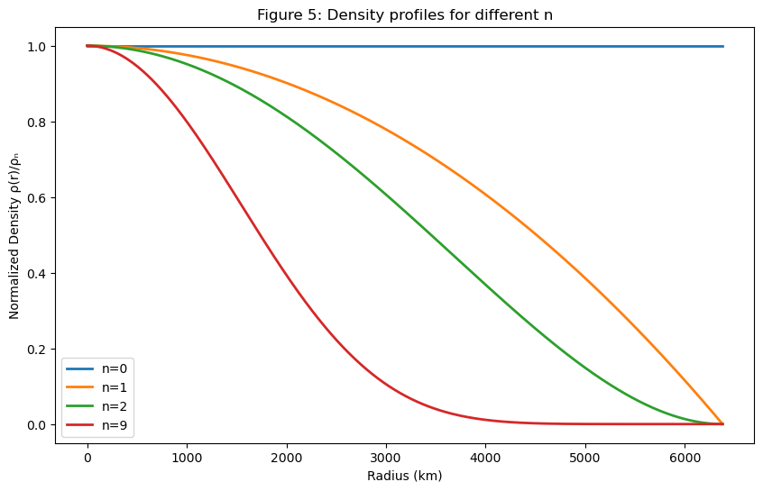

```python
#define the funciton for normalized density
def rho_normalized(r, n):
    return (1 - (r/R_e)**2)**n

#plot for n = 0, 1, 2, 9
r_vals = np.linspace(0, R_e, 1000)
ns = [0, 1, 2, 9]

fig, ax = plt.subplots(figsize=(10, 6))
for n in ns:
    rho_vals = [rho_normalized(r, n) for r in r_vals] #mmmm fors within fors
    ax.plot(r_vals/1000, rho_vals, label=f'n={n}', linewidth=2)

ax.set_xlabel('Radius (km)')
ax.set_ylabel('Normalized Density ρ(r)/ρₙ')
ax.set_title('Figure 5: Density profiles for different n')
ax.legend()

#compute totla mass so that it = M_e
def compute_rho_n(n):
    def intg(r):
        return (1 - (r/R_e)**2)**n * r**2

    integral, _ = quad(intg, 0, R_e)
    rho_n = M_e / (4 * np.pi * integral)
    return rho_n

rho_n_values = {}
for n in ns:
    rho_n_values[n] = compute_rho_n(n)
    print(f"n={n}: ρ_n = {rho_n_values[n]:.2e} kg/m^3")
```

### Part 5, Section B (Forces)

```
All curves should reach g = 9.81 m/s^2 at surface (validates rho_n)
```

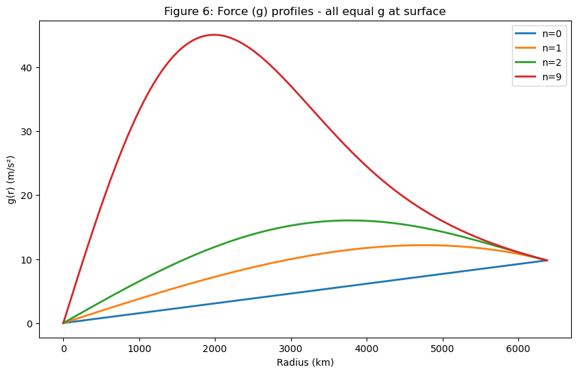

```python
#define func for mass inside radius r
def mass_inside_r(r, n, rho_n):
    def integrand(r_prime):
        return (1 - (r_prime/R_e)**2)**n * r_prime**2

    integral, _ = quad(integrand, 0, r)
    return 4 * np.pi * rho_n * integral

#define func for force per unit mass at radius r
def force_at_r(r, n, rho_n):
    if r == 0:
        return 0
    M_r = mass_inside_r(r, n, rho_n)
    return G * M_r / r**2

fig, ax = plt.subplots(figsize=(10, 6))
for n in ns:
    force_vals = [force_at_r(r, n, rho_n_values[n]) for r in r_vals]
    ax.plot(r_vals/1000, force_vals, label=f'n={n}', linewidth=2)

ax.set_xlabel('Radius (km)')
ax.set_ylabel('g(r) (m/s²)')
ax.set_title('Figure 6: Force (g) profiles - all equal g at surface')
ax.legend()
print("All curves should reach g = 9.81 m/s^2 at surface (validates rho_n)")
```

### Part 5, Section C (Equations of Motion)

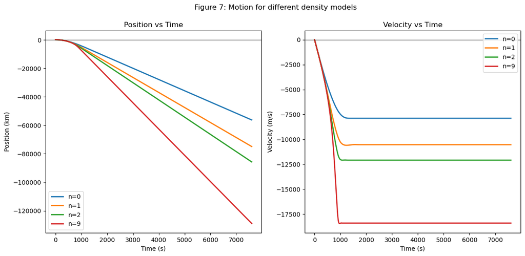

```python
#part 3
def motion_nonuniform(t, state, n, rho_n):
    y, v = state
    r = R_e + y
    if r > 0:
        g_r = force_at_r(r, n, rho_n)
    else:
        g_r = 0
    dydt = v
    dvdt = -g_r
    return [dydt, dvdt]

#solve for each n
solutions_n = {}
fig, (ax1, ax2) = plt.subplots(1, 2, figsize=(14, 6))

for n in ns:
    sol = solve_ivp(lambda t, y: motion_nonuniform(t, y, n, rho_n_values[n]), t_span_long, init0, t_eval=t_eval_long, dense_output=True)
    solutions_n[n] = sol

    ax1.plot(sol.t, sol.y[0]/1000, label=f'n={n}', linewidth=2)
    ax2.plot(sol.t, sol.y[1], label=f'n={n}', linewidth=2)

ax1.set_xlabel('Time (s)')
ax1.set_ylabel('Position (km)')
ax1.set_title('Position vs Time')
ax1.legend()
ax1.axhline(0, color='black', linewidth=0.5)

ax2.set_xlabel('Time (s)')
ax2.set_ylabel('Velocity (m/s)')
ax2.set_title('Velocity vs Time')
ax2.legend()
ax2.axhline(0, color='black', linewidth=0.5)

plt.suptitle('Figure 7: Motion for different density models')
```

```python
#part 4
for n in ns:
    sol = solutions_n[n]
    center_idx = np.argmin(np.abs(sol.y[0] + R_e))
    t_center = sol.t[center_idx]
    v_center = abs(sol.y[1][center_idx])
    print(f"n={n}: Time to center = {t_center:.1f} s, Speed = {v_center:.1f} m/s")
```

```
n=0: Time to center = 1266.2 s, Speed = 7876.7 m/s
n=1: Time to center = 1095.1 s, Speed = 10510.1 m/s
n=2: Time to center = 1034.2 s, Speed = 12080.6 m/s
n=9: Time to center = 943.0 s, Speed = 18398.4 m/s
```

## Part 6: A Lunar Mine Shaft

Finally, with all of the framework in place, consider the case where the the mine shaft is instead dug on the moon.

1. Compute the travel time to the center of the moon in case we dig a pole-to-pole mine shaft, so that we can again avoid the Coriolis force, though on the moon this force is very small. No drag force either, which is actually realistic for the moon!
2. What is the density (if you asssume a constant density) of the moon compared to that of earth?
3. How does the fall/orbit time depend on density? See if you can discover a relationship between the density and the fall time. You should think beyond strictly linear relationships.

This problem can actually be done on paper, and then you can compare the answer with that for the homogenous earth you did in Part 4.

```python
g_moon = G * M_m / R_m**2
print(f"Surface gravity on Moon: {g_moon:.3f} m/s²")

#define the moon motion equationn
def motion_moon(t, state):
    y, v = state
    r = R_m + y
    g_r = g_moon * r / R_m  # linear decrease (uniform density)
    dydt = v
    dvdt = -g_r
    return [dydt, dvdt]

T_moon = 2 * np.pi * np.sqrt(R_m / g_moon)
t_span_moon = (0, T_moon)
t_eval_moon = np.linspace(0, T_moon, 2000)

sol_moon = solve_ivp(motion_moon, t_span_moon, init0,
                     t_eval=t_eval_moon, dense_output=True)

#find time to center
center_idx_moon = np.argmin(np.abs(sol_moon.y[0] + R_m))
t_center_moon = sol_moon.t[center_idx_moon]

print(f"Time to center of Moon: {t_center_moon:.1f} s = {t_center_moon/60:.1f} min")
print(f"Time to center of Earth: {T_analytical/4:.1f} s = {T_analytical/4/60:.1f} min")
```

[output not shown]

```python
rho_earth = M_e / (4/3 * np.pi * R_e**3)
rho_moon = M_m / (4/3 * np.pi * R_m**3)

print(f"Earth density: {rho_earth:.0f} kg/m³")
print(f"Moon density: {rho_moon:.0f} kg/m³")
print(f"Ratio (Moon/Earth): {rho_moon/rho_earth:.3f}")
```

```
Earth density: 5495 kg/m³
Moon density: 3342 kg/m³
Ratio (Moon/Earth): 0.608
```

The density of the moon is about 60% of that of the earth (assuming a constant density throughout)

```python
#for uniform density sphere: T = 2*pi*sqrt(R/g) = 2*pi*sqrt(R/(GM/R^2))
#                            T = 2*pi*sqrt(R^3/GM)
#but M = (4/3)*pi*R^3*rho, so GM = G*(4/3)*pi*R^3*rho
#therefore: T = 2*pi*sqrt(R^3 / (G*(4/3)*pi*R^3*rho))
#           T = 2*pi*sqrt(1 / (G*(4/3)*pi*rho))
#           T = sqrt(3*pi / (G*rho))
# So T is proportional to 1/sqrt(rho)

T_earth_predicted = np.sqrt(3*np.pi / (G*rho_earth))
T_moon_predicted = np.sqrt(3*np.pi / (G*rho_moon))

print(f"Earth period (analytical): {T_earth_predicted:.1f} s")
print(f"Moon period (analytical): {T_moon_predicted:.1f} s")
print(f"Fall time proportional to 1/sqrt(density)")
print(f"Ratio of times (Moon/Earth): {T_moon_predicted/T_earth_predicted:.3f}")
print(f"Ratio of 1/sqrt(densities): {np.sqrt(rho_earth/rho_moon):.3f}")
print("They match")
```

```
Earth period (analytical): 5069.4 s
Moon period (analytical): 6500.5 s
Fall time proportional to 1/sqrt(density)
Ratio of times (Moon/Earth): 1.282
Ratio of 1/sqrt(densities): 1.282
They match
```

#### Part 3

for uniform density sphere: $$T = 2\pi\sqrt{R/g} = 2\pi\sqrt{R/(GM/R^2)}$$ $$T = 2\pi\sqrt{R^3/GM}$$ but $M = (4/3)\pi R^3\rho$, so $$GM = G(4/3)\pi R^3\rho$$ therefore $$T = 2\pi\sqrt{\frac{R^3}{G(4/3)\pi R^3\rho}}$$ $$T = 2\pi\sqrt{\frac{1}{G(4/3)\pi\rho}}$$ $$T = \sqrt{\frac{3\pi}{G\rho}}$$

#### So T should be proportional to $1/\sqrt{rho}$, which will be checked below:

```python
T_earth_predicted = np.sqrt(3*np.pi / (G*rho_earth))
T_moon_predicted = np.sqrt(3*np.pi / (G*rho_moon))

print(f"Earth period (analytical): {T_earth_predicted:.1f} s")
print(f"Moon period (analytical): {T_moon_predicted:.1f} s")
print(f"Fall time proportional to 1/sqrt(density)")
print(f"Ratio of times (Moon/Earth): {T_moon_predicted/T_earth_predicted:.3f}")
print(f"Ratio of 1/sqrt(densities): {np.sqrt(rho_earth/rho_moon):.3f}")
if np.isclose(np.sqrt(rho_earth/rho_moon), T_moon_predicted/T_earth_predicted):
    print(f'\nThe ratios match')
```

```
Earth period (analytical): 5069.4 s
Moon period (analytical): 6500.5 s
Fall time proportional to 1/sqrt(density)
Ratio of times (Moon/Earth): 1.282
Ratio of 1/sqrt(densities): 1.282

The ratios match
```

## Part 7: Fourier Transforming Orbits

Take the solutions for n=0 and n=9 of the orbits in Part 5 (the inhomogeneous earth) and Fourier Transform them, to see what frequencies (*1/periods*) are dominant in the power spectra. Comment on what you see.

**Hint:** you could take the orbit from the previous integration in Part 5c, but it is useful to increase the integration time and sampling to get more meaningful smooth enough curves. We discussed this in class.

For an example of a spectral analysis of galactic orbits see https://articles.adsabs.harvard.edu/pdf/1982ApJ...252..308B

```
n=0:
 Dominant frequency: 1.973292e-05 Hz
 Dominant period: 50676.7 s = 844.6 min

n=9:
 Dominant frequency: 1.973292e-05 Hz
 Dominant period: 50676.7 s = 844.6 min
```

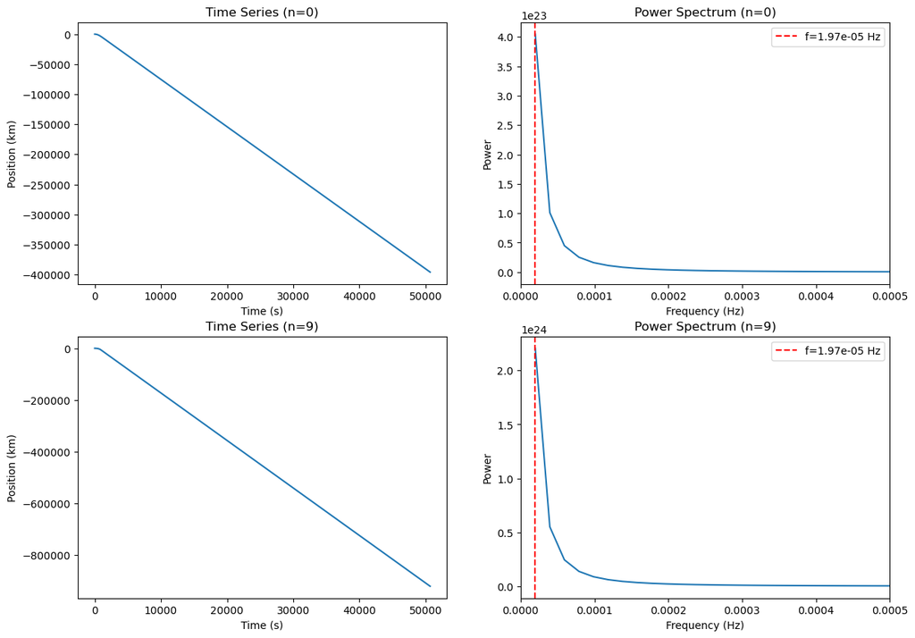

```python
#need longer integration and finer sampling for good FFT
t_span_fft = (0, 10 * T_analytical)
n_points = 10000
t_eval_fft = np.linspace(t_span_fft[0], t_span_fft[1], n_points)

#integrate for n=0 and n=9
solutions_fft = {}
for n in [0,9]:
    sol = solve_ivp(lambda t, y: motion_nonuniform(t, y, n, rho_n_values[n]), t_span_fft, init0, t_eval=t_eval_fft, dense_output=True)
    solutions_fft[n] = sol

#perform FFT and plot
fig, axes = plt.subplots(2, 2, figsize=(14, 10))

for i, n in enumerate([0, 9]):
    sol = solutions_fft[n]

    #time series
    axes[i,0].plot(sol.t, sol.y[0]/1000)
    axes[i,0].set_xlabel('Time (s)')
    axes[i,0].set_ylabel('Position (km)')
    axes[i,0].set_title(f'Time Series (n={n})')

    #FFT
    y_data = sol.y[0]
    dt = sol.t[1] - sol.t[0]

    yf = fft(y_data)
    xf = fftfreq(n_points, dt)

    #only positive frequencies
    pos_mask = xf > 0
    xf_pos = xf[pos_mask]
    yf_pos = np.abs(yf[pos_mask])
    power = yf_pos**2

    axes[i,1].plot(xf_pos, power)
    axes[i,1].set_xlabel('Frequency (Hz)')
    axes[i,1].set_ylabel('Power')
    axes[i,1].set_title(f'Power Spectrum (n={n})')
    axes[i,1].set_xlim(0, 0.0005)

    #find dominant frequency
    max_idx = np.argmax(power)
    dominant_freq = xf_pos[max_idx]
    dominant_period = 1 / dominant_freq

    print(f"n={n}:")
    print(f" Dominant frequency: {dominant_freq:.6e} Hz")
    print(f" Dominant period: {dominant_period:.1f} s = {dominant_period/60:.1f} min\n")

    axes[i,1].axvline(dominant_freq, color='red', linestyle='--', label=f'f={dominant_freq:.2e} Hz')
    axes[i,1].legend()
```